# BAIT507: Mobi Bike Share

Prapon Wongsangaroonsri, Mohammad Heshmat, Sherry Qin, and Lorraine Xue

9/28/2019

## *Section 1*: Problem Statement - Bike Share in Vancouver

The industry of bike sharing, which has just emerged in recent years with the rapid development of sharing-economy, refers to the bike sharing service provided by enterprises on campus, subway station, bus station, residential area, commercial area and other public service area. It’s not only a time-sharing lease mode but also a new type of green environmental protection sharing economy. In addition, bike sharing is essentially a new type of vehicle rental business - bicycle rental business, which relies mainly on cycling bicycles. Regarding its advantages, it can make full use of the bicycle stagnation caused by the rapid economic development of the city, and maximize the utilization of public road passing rate.

Although the future of bike sharing seems to be prosperous, the whole industry has encountered several questions. For example, the competition of this industry becomes extremely intense with more and more bike sharing companies entering the industry. What is more, the company find it difficult to cultivate the user loyalty, since it makes no difference for users to choose any sharing bikes. Last but not the least, the high operating cost is another problem the bike sharing company has to face.

Many bike sharing companies have already withdrawn from the industry, but there are also companies that survive the winter. We believe that the market for bike sharing is still big. After all, the sharing economy is the inevitable result of social development. We should take warning from those examples and consider how a bike sharing company can create and acquire consumer demands and then make more profit, as a consequence, we have chosen this topic and focus on Mobi to research the methods which help bike sharing companies more profitable. As a Vancouver-based bike sharing company, Mobi was launched in July 2016 in Vancouver and currently has 1500 bicycles with 150 stations in Vancouver. Mobi is still in the dominant status of this industry at present, but it is undeniable that the sky train, uber and taxi could affect citizens’ trip modes. Consequently, our topic will focus on two perspectives to help Mobi solidify its position and gain more customers: the imbalance of sharing bike distributions and the weather effect on bike usage.

## *Section 2*: Data Sources

In order to solve our issue, we have found several datasets after considering the essential factors, which include the bike datasets that we downloaded from data.world and the weather datasets that we obtained from the official Canadian weather website. After comparing these different datasets, we drop out several undetailed datasets which do not conclude enough information, and finally choose Mobi 2018 dataset and the Vancouver weather dataset of 2018.

The reason why we choose Mobi 2018 is that firstly, the target biking sharing company that we mainly focus is Mobi, due to that Mobi is not only located in Vancouver where we are living and familiar with, but also it has the largest bike sharing users. Furthermore, the weather dataset that we have chosen is provided by the Canadian government, which is a reliable resource and thus, would be suitable for our topic.

For the data-set, the link are provided below as the website does not allow the files to be downloaded directly.

1. Weather Data Set: https://climate.weather.gc.ca/climate_data/daily_data_e.html?StationID=51442&timeframe=2&StartYear=1840&EndYear=2019&Day=3&Year=2018&Month=10#
2. Bike Data Set: https://data.world/michellecho/vancouver-bike-sharing-2018

## Section 3 & 4: Data Feature and Model

Our overall data structure contains 4 separate tables linking to the main mobi data set by unique id’s. The structure is illustrated in the figure below.

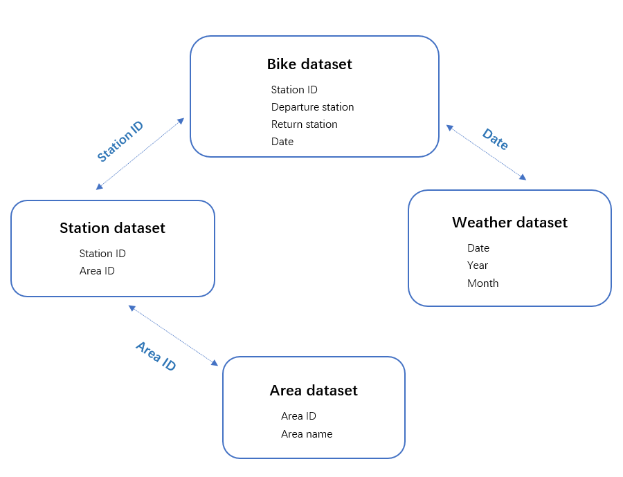

Figure 1:Database Structure

The following section contains further details on all of the data cleaning/structuring process for each of our data set.

### Data Cleaning and Processing (Bike-Share)

Since the Mobi bike-share data set is collected separately at a month level, we starts with 12 files for each month and, by the end, we would join these data-set together to form a single bike data set for 2018.

```r
library(RPostgreSQL)
```

```r
library(backports)
library(readr)
library(ggplot2)
```

```r
mobi0118 = read.csv(file = "Bike-share Data/Mobi_System_Data_2018-01.csv",header = TRUE)
mobi0218 = read.csv(file = "Bike-share Data/Mobi_System_Data_2018-02.csv",header = TRUE)
mobi0318 = read.csv(file = "Bike-share Data/Mobi_System_Data_2018-03.csv",header = TRUE)
mobi0418 = read.csv(file = "Bike-share Data/Mobi_System_Data_2018-04.csv",header = TRUE)
mobi0518 = read.csv(file = "Bike-share Data/Mobi_System_Data_2018-05.csv",header = TRUE)
mobi0618 = read.csv(file = "Bike-share Data/Mobi_System_Data_2018-06.csv",header = TRUE)
mobi0718 = read.csv(file = "Bike-share Data/Mobi_System_Data_2018-07.csv",header = TRUE)
mobi0818 = read.csv(file = "Bike-share Data/Mobi_System_Data_2018-08.csv",header = TRUE)
mobi0918 = read.csv(file = "Bike-share Data/Mobi_System_Data_2018-09.csv",header = TRUE)
mobi1018 = read.csv(file = "Bike-share Data/Mobi_System_Data_2018-10.csv",header = TRUE)
mobi1118 = read.csv(file = "Bike-share Data/Mobi_System_Data_2018-11.csv",header = TRUE)
mobi1218 = read.csv(file = "Bike-share Data/Mobi_System_Data_2018-12.csv",header = TRUE)
```

To start the join process, we first has to rename all the columns in the data set to correct for naming inconsistencies for some of the data-set as well as to have simpler name for each columns. The data set for September also contains two extra columns on departure and return slots which doesn’t exist in other tables and has to be removed to join with the others.

```r
mobi0918[c(16:17)] <- NULL

new_names <- c("depart","arrive","account","bike","d_station","r_station","type","dist","time","dvolt","rvolt","dtemp","rtemp","stop_time","stop_num")

# Mutate mobi0118
colnames(mobi0118)[1:15] <- new_names
colnames(mobi0218)[1:15] <- new_names
colnames(mobi0318)[1:15] <- new_names
colnames(mobi0418)[1:15] <- new_names
colnames(mobi0518)[1:15] <- new_names
colnames(mobi0618)[1:15] <- new_names
colnames(mobi0718)[1:15] <- new_names
colnames(mobi0818)[1:15] <- new_names
colnames(mobi0918)[1:15] <- new_names
colnames(mobi1018)[1:15] <- new_names
colnames(mobi1118)[1:15] <- new_names
colnames(mobi1218)[1:15] <- new_names

#Combining All Months/Mobi Data
mobi2018 <- rbind(mobi0118, mobi0218, mobi0318,mobi0418, mobi0518,mobi0618,mobi0718,mobi0818,mobi0918,mobi1018,mobi1118)
rm(mobi0118, mobi0218, mobi0318,mobi0418, mobi0518,mobi0618,mobi0718,mobi0818,mobi0918,mobi1018,mobi1118)
```

For the first combination, we could only combine the data from M1 to M11, since the way in which the date is encoded in the data set for M12 is slightly different. For M1 - M11, date is in the ‘MM/DD/YYYY’ format, while M12 is in ‘YYYY-MM-DD’ format. To correct for this different, we split the date time into three columns for day, month, year with an additional column for hour of departure and return in a day. Once date has been correct, we join the M12 data set with the M1 to M11 to form an entire 2018 bike data-set.

```r
mobi2018$depart = as.character(mobi2018$depart)
mobi2018$arrive = as.character(mobi2018$arrive)

mobi2018['dep_month'] = sapply(strsplit(mobi2018$depart, "[\\/ |\\: | ]"), `[`, 1)
mobi2018['dep_day'] = sapply(strsplit(mobi2018$depart, "[\\/ |\\: | ]"), `[`, 2)
mobi2018['dep_year'] = sapply(strsplit(mobi2018$depart, "[\\/ |\\: | ]"), `[`, 3)
mobi2018['dep_hour'] = sapply(strsplit(mobi2018$depart, "[\\/ |\\: | ]"), `[`, 4)

mobi2018['ret_month'] = sapply(strsplit(mobi2018$arrive, "[\\/ |\\: | ]"), `[`, 1)
mobi2018['ret_day'] = sapply(strsplit(mobi2018$arrive, "[\\/ |\\: | ]"), `[`, 2)
mobi2018['ret_year'] = sapply(strsplit(mobi2018$arrive, "[\\/ |\\: | ]"), `[`, 3)
mobi2018['ret_hour'] = sapply(strsplit(mobi2018$arrive, "[\\/ |\\: | ]"), `[`, 4)

mobi2018$depart <- NULL
mobi2018$arrive <- NULL

mobi1218$depart = as.character(mobi1218$depart)
mobi1218$arrive = as.character(mobi1218$arrive)

mobi1218['dep_year'] = sapply(strsplit(mobi1218$depart, "[- |\\: | ]"), `[`, 1)
mobi1218['dep_month'] = sapply(strsplit(mobi1218$depart, "[- |\\: | ]"), `[`, 2)
mobi1218['dep_day'] = sapply(strsplit(mobi1218$depart, "[- |\\: | ]"), `[`, 3)
mobi1218['dep_hour'] = sapply(strsplit(mobi1218$depart, "[- |\\: | ]"), `[`, 4)

mobi1218['ret_year'] = sapply(strsplit(mobi1218$arrive, "[- |\\: | ]"), `[`, 1)
mobi1218['ret_month'] = sapply(strsplit(mobi1218$arrive, "[- |\\: | ]"), `[`, 2)
mobi1218['ret_day'] = sapply(strsplit(mobi1218$arrive, "[- |\\: | ]"), `[`, 3)
mobi1218['ret_hour'] = sapply(strsplit(mobi1218$arrive, "[- |\\: | ]"), `[`, 4)

mobi1218$depart <- NULL
mobi1218$arrive <- NULL

mobi2018 <- rbind(mobi2018, mobi1218)
rm(mobi1218)

View(mobi2018)
```

Running some basic summary statistics of the data set shows that there is a significant outliers in the duration and time columns. At the maximum, the data shows 481,050 kilometers biked and 1,752,699 seconds, which is most likely a result of coding errors. Instead, to correct for this, we drop the rows with the top and bottom 1% in the data set (as well as eliminated rows with zero entries for time or distance). Since more than 1% of the sample has their distance travelled at 0, we choose to set the lower boundary of distance travelled at 0 instead of 1% value.

```r
dist_tpct = sort(mobi2018$dist, decreasing = TRUE)[round(length(mobi2018$dist)*.01,0)]
dist_bpct = sort(mobi2018$dist, decreasing = TRUE)[round(length(mobi2018$dist)*.99,0)]
time_tpct = sort(mobi2018$time, decreasing = TRUE)[round(length(mobi2018$time)*.01,0)]
time_bpct = sort(mobi2018$time, decreasing = TRUE)[round(length(mobi2018$time)*.99,0)]


# Dropping top/bottom 1% of time and distance as well as zero entries
mobi2018<-mobi2018[mobi2018$dist < dist_tpct,]
mobi2018<-mobi2018[mobi2018$dist > 0,]
mobi2018<-mobi2018[mobi2018$time < time_tpct,]
mobi2018<-mobi2018[mobi2018$time > time_bpct,]
```

Lastly, to put the data in first normal form, we then split out the area_id from the name of departing station and returning station, since there will be duplicate stations for all the trips. The station name would then be stored in a separate station table, which is linked to the main data set, using area ID. Lastly, we removed the variable which would not be necessary to our analysis.

```r
toString(mobi2018$d_station)
mobi2018['dep_id'] = substr(mobi2018$d_station, 1, 4)
mobi2018$d_station <- NULL


toString(mobi2018$r_station)
mobi2018['ret_id'] = substr(mobi2018$r_station, 1, 4)
mobi2018$r_station <- NULL


mobi2018$type <- NULL
mobi2018$dvolt <- NULL
mobi2018$rvolt <- NULL
```

With this, we conclude the cleaning process for the main bike-share data set.

### Data Cleaning and Processing (Weather)

For the weather data, we imported the data in directly as csv file and filter only the column we would need for the analysis. The columns are renamed for simplicity. Since the date in the weather data is already build as separate columns for year, month, and day. This matches with our format for date data in the bike-share data, which would allows weather and bike-share to be joined on the date dimension in the later section of the report.

```r
weather = read.csv(file = "Bike-share Data/Vancouver_Weather_Data_2018.csv", skip = 25, header = TRUE)

colnames(weather)[1] = "year"
colnames(weather)[2] = "month"
colnames(weather)[3] = "day"
colnames(weather)[5] = "max_temp"
colnames(weather)[7] = "min_temp"
colnames(weather)[9] = "mean_temp"
colnames(weather)[15] = "rain_mm"
colnames(weather)[17] = "snow_cm"
colnames(weather)[19] = "precip_mm"
colnames(weather)[21] = "grndsnow_cm"
colnames(weather)[25] = "gust"
weather = weather[-c(4,6,8,10:14,16,18,20,22:24,26)]
```

### Data Cleaning and Processing (Neighborhood)

Using the composite map of all Mobi bike share stations in Vancouver from MountainMath.org, which contains all the current stations of Mobi and their locations as per the figure below.

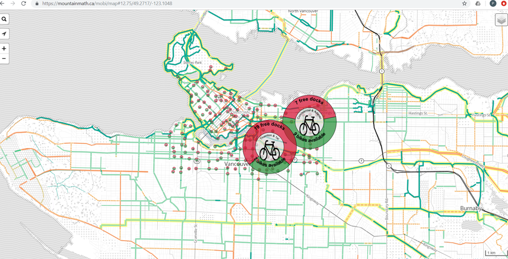

Figure 2: Station Location

Using neighborhood map from Wikipedia.org, we map each statio to a specific neighborhood. From this we create a data-set which map the stations to eight neighborhoods in Vancouver in which Mobi is operating. These includes:

1. Stanley Park
2. Westend
3. Downtown
4. Downtown Eastside
5. Strathcona
6. Mount Pleasant
7. Fairview
8. Grandview-Woodland

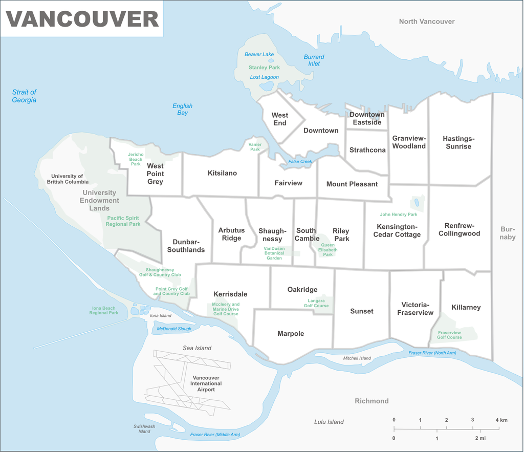

Figure 3: Vancouver Neighborhood Map

From this we manually created two tables: ‘station’ and ‘neighborhood.’  
‘station_id’ maps unique station name to each departing and returning station for a bike trip in the main data-set. ‘neighborhood’ table has unique id for each of Vancouver neighborhood above, which is then mapped to the ‘station’ table, using these area_id. While we are aware that better mapping method exists by using GPD coordinate. We choose this method for its simplicity under the given time constraints.

For the section below, we import that csv files for station and area as data-frame to be pushed into Postgres. To get the station ID in the station table, we extract the first four digit of station name, which matches with station id in the main data set.

```r
station = read.csv(file = "Bike-share Data/Stations.csv",header = TRUE)
colnames(station)[1] = 'station_id'
colnames(station)[2] = 'station_name'
colnames(station)[3] = 'area_id'
station['station_id'] = substr(station$station_name, 1, 4)

area = read.csv(file = "Bike-share Data/Area.csv",header = TRUE)
```

### Pushing the data to Postgres

```r
pw = readr::read_lines("db_pw.txt")

con <- dbConnect(PostgreSQL(),
                 host = "localhost",
                 port = 5432,
                 user = "postgres",
                 password = pw,
                 dbname = "Bike_Share")
```

```r
dbWriteTable(con,
             name = "bike_data",
             mobi2018, overwrite = TRUE, rowname = FALSE)

dbWriteTable(con,
             name = "neighborhood",
             area, overwrite = TRUE, rowname = FALSE)

dbWriteTable(con,
             name = "station",
             station, overwrite = TRUE, rowname = FALSE)

dbWriteTable(con,
             name = "weather",
             weather, overwrite = TRUE, rowname = FALSE)
```

# **Section 5: Data Analysis and Discussion**

To address our central questions regarding the profitability of Mobi, we are tackling the problem on two separate angles.

1. *Demand Side*: For revenue, we are looking at the frequency in which customers rent Mobi Bike to establish the dimension and areas in high activity is high so that the company would be able to fous their effort in time and places with high demand.
2. *Cost Side*: For cost, the main cost we are trying to address is the cost of redistributing bikes to each station. Since the customers of bike-sharing service seldom return the bikes to the same station, this could lead to an shortage of bike in station with high departure rate (eg. residential area) and excess in the stations with high return rate (eg. near public transit). To address this, the company would have to physically redistribute the bikes back to where there is demand. As each move would require manpower, thus incurring cost, studying the pattern of this imbalance will allow the bikes to be redistributed more effectively.

To begin our analysis, we are sending query to postgres to summarize data into smaller chunks for visualization. Since the data in the main data set is in the level of individual bike trip, we are counting the frequencies of departing trips over different time, area dimensions to capture the level of activities.

```r
bikes = dbGetQuery(con,"
SELECT account, COUNT(d_station) as trips
FROM mobi2018
GROUP BY account
ORDER BY trips DESC; ")

Area = dbGetQuery(con,"
SELECT T1.d_station,
  ROUND(AVG(T1.time)) as duration,
  T3.area_name
FROM mobi2018 as T1
  LEFT JOIN (SELECT * FROM station) as T2 ON T1.d_station = T2.station_name
  LEFT JOIN (SELECT area_ID, area_name FROM neighborhood) as T3 ON T2.area_id = T3.area_id
WHERE area_name IS NOT NULL AND d_station IS NOT NULL
GROUP BY T1.d_station, T3.area_name ;")

freq_Area = dbGetQuery(con,"
SELECT T1.d_station,
  COUNT(*) as frequency,
  T3.area_name
FROM mobi2018 as T1
  LEFT JOIN (SELECT * FROM station) as T2 ON T1.d_station = T2.station_name
  LEFT JOIN (SELECT area_ID, area_name FROM neighborhood) as T3 ON  T2.area_id = T3.area_id
WHERE area_name IS NOT NULL AND d_station IS NOT NULL
GROUP BY T1.d_station, T3.area_name;")


duration_hour =  dbGetQuery(con,"
SELECT dep_hour, ROUND(AVG(time)) as duration
FROM mobi2018
GROUP BY dep_hour;")

freq_hour = dbGetQuery(con,"
SELECT dep_hour, COUNT(d_station) as frequency
FROM mobi2018
GROUP BY dep_hour;")

freq_weather = dbGetQuery(con,"
SELECT T1.num_dep,
  T2.num_ret,
  (T1.num_dep - T2.num_ret) as imbalance,
  dep_month,
  dep_day,
  ret_month,
  max_temp,
  min_temp,
  mean_temp,
  rain_mm,
  gust
FROM (SELECT dep_month, dep_day, COUNT(*) as num_dep FROM mobi2018 GROUP BY dep_month, dep_day) as T1
  INNER JOIN (SELECT ret_month, ret_day, COUNT(*) as num_ret FROM mobi2018 GROUP BY          ret_month, ret_day) as T2 ON dep_month = ret_month AND dep_day = ret_day
  INNER JOIN (SELECT day, month, year, max_temp, min_temp, mean_temp, rain_mm, gust FROM     weather) as T3 ON T1.dep_day = T3.day AND T1.dep_month = T3.month
ORDER BY imbalance DESC")

imb_Area_new = dbGetQuery(con,"
SELECT SUM(T1.num_dep) as num_dep,
  SUM(T2.num_ret) as num_ret,
  (SUM(T1.num_dep) - SUM(T2.num_ret)) as imbalance,
  area_name
FROM (SELECT d_station, COUNT(*) as num_dep FROM mobi2018 GROUP BY d_station) as T1
  INNER JOIN (SELECT r_station, COUNT(*) as num_ret FROM mobi2018 GROUP BY r_station) as T2   ON d_station = r_station
  INNER JOIN (SELECT station_name,area_id FROM station) as T3 ON d_station = station_name
  INNER JOIN (SELECT area_name,area_id FROM neighborhood) as T4 ON T3.area_id = T4.area_id
WHERE area_name IS NOT NULL
GROUP BY area_name
ORDER BY imbalance DESC;")

freq_rain  = dbGetQuery(con,"
SELECT ROUND(AVG(T1.num_dep)) as avg_dep,
    ROUND(AVG(T2.num_ret))as avg_ret,
    ROUND(AVG(duration)) as avg_duration,
    ROUND(AVG(mean_temp)) as avg_temp,
    ROUND(AVG(rain_mm)) as avg_rain,
    T3.rainlevel
FROM (SELECT dep_month, dep_day, COUNT(*) as num_dep, AVG(time) as duration FROM mobi2018 GROUP BY dep_month, dep_day) as T1
  INNER JOIN (SELECT ret_month, ret_day, COUNT(*) as num_ret FROM mobi2018 GROUP BY          ret_month, ret_day) as T2
  ON dep_month = ret_month AND dep_day = ret_day
  INNER JOIN (SELECT day, month, year, max_temp, min_temp, mean_temp, rain_mm, gust,         rainlevel FROM weather) as T3 ON T1.dep_day = T3.day AND T1.dep_month = T3.month
WHERE rainlevel IS NOT NULL
GROUP BY T3.rainlevel
ORDER BY rainlevel DESC
")
```

## Graphs

The section below contains all the main graphs with a brief commentaries regarding the insights we’ve obtained from each of these graphs.

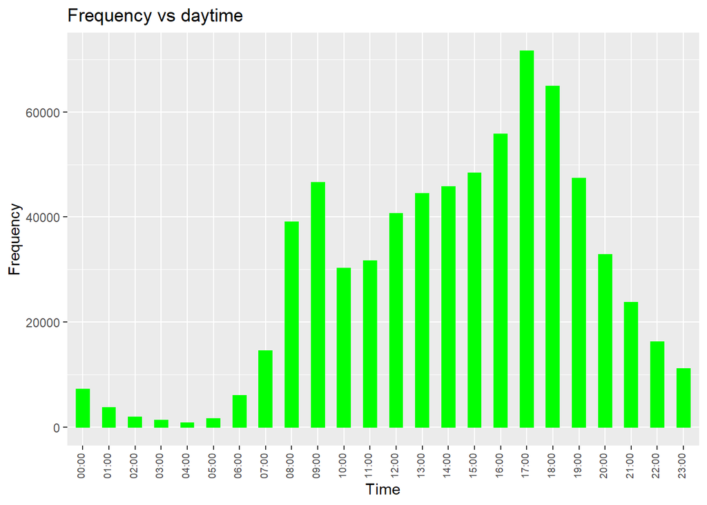

```r
label3<-c("00:00","01:00","02:00","03:00","04:00","05:00",
          "06:00","07:00","08:00","09:00","10:00","11:00",
          "12:00","13:00","14:00","15:00","16:00","17:00",
          "18:00","19:00","20:00","21:00","22:00","23:00")
label3<-factor(label3,levels = label3)
g <- ggplot(data = freq_hour, aes(x=dep_hour,y=frequency)) + scale_fill_brewer(palette = "Spectral")
g <- g + geom_bar(aes(x=label3,y=frequency), stat="identity" ,fill="green",col="green",width = 0.5) +
  theme(axis.text.x = element_text(angle=90, vjust=0.2, size=7)) +
  labs(title="Frequency vs daytime")+xlab("Time")+ylab("Frequency")
ggsave("output/Frequency-time.jpg", units="in", width=10, height=8, dpi=300)
g
```

We firstly generate this graph. The x axis is time and y axis is frequency. For example, throughout 2018, between 7-8am in the morning of each day, there are total around 15,000 times of bike have been riding. By looking at this chart, we can see a trend that the high volume of usage typically happens between 8am-8pm, with the peak at around 4-6pm. And by knowing this, we can adjust the price accordingly such as increase the price a little bit during the peak time and decrease the price or give some coupon before 8am and after 8pm to encourage more demand.

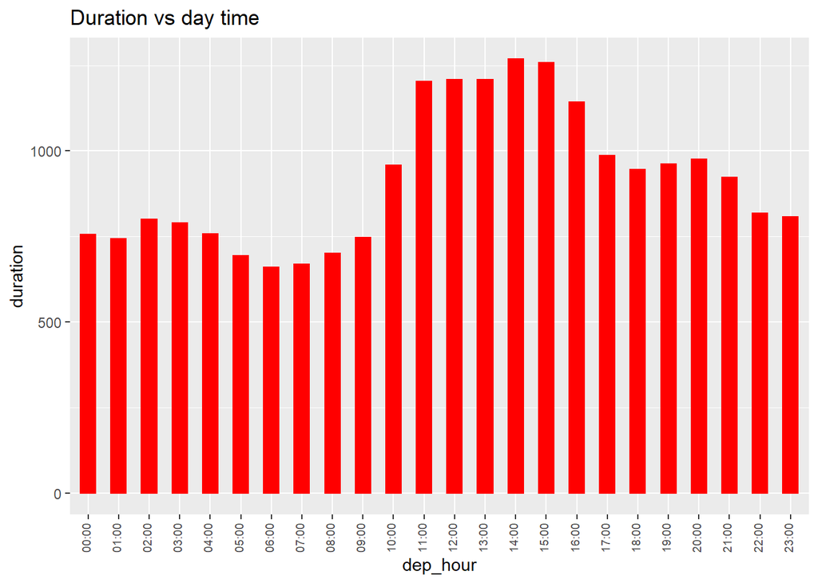

```r
label1<-c("00:00","01:00","02:00","03:00","04:00","05:00",
           "06:00","07:00","08:00","09:00","10:00","11:00",
         "12:00","13:00","14:00","15:00","16:00","17:00",
           "18:00","19:00","20:00","21:00","22:00","23:00")

g <- ggplot(data = duration_hour, aes(x=dep_hour,y=duration)) + scale_fill_brewer(palette = "Spectral")
g <- g + geom_bar(aes(x=label1,y=duration), stat="identity" ,fill="red",col="red",width = 0.5) +
  theme(axis.text.x = element_text(angle=90, vjust=0.2, size=7)) +
  labs(title="Duration vs day time")
ggsave("output/duration-Time.tiff", units="in", width=20, height=8, dpi=300, compression = 'lzw')
g
```

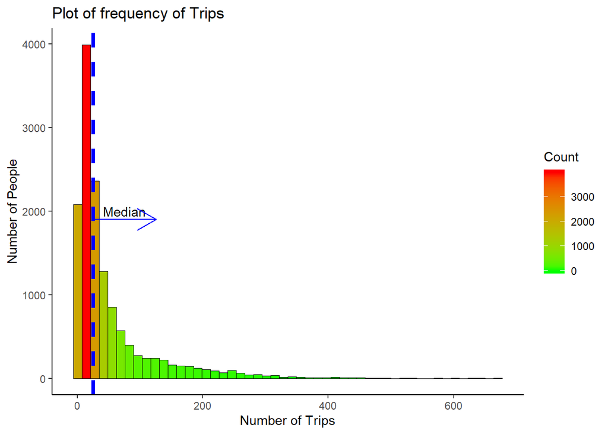

```r
theme_set(theme_classic())
gp<-ggplot(data=bikes, aes(bikes$trips)) +
           geom_histogram(bins=50,col="black", size=0.1, aes(fill=..count..))+
          scale_fill_gradient("Count", low="green", high="red")
gp<- gp + geom_vline(xintercept = median(bikes$trips), linetype="dashed", color = "blue", size=1.5)+
        annotate("text", x = median(bikes$trips)+50, y = 2000, label = "Median")+
       geom_segment(x = median(bikes$trips),y = 1900,xend = median(bikes$trips)+100,yend = 1900,arrow=arrow(), size=0.5, color="blue")
gp<-gp + ggtitle("Plot of frequency of Trips") +
  xlab("Number of Trips") + ylab("Number of People")
ggsave("output/Number of people - number of trips.tiff", units="in", width=20, height=8, dpi=300, compression = 'lzw')
gp
```

```r
median(bikes$trips)
```

```
## [1] 25
```

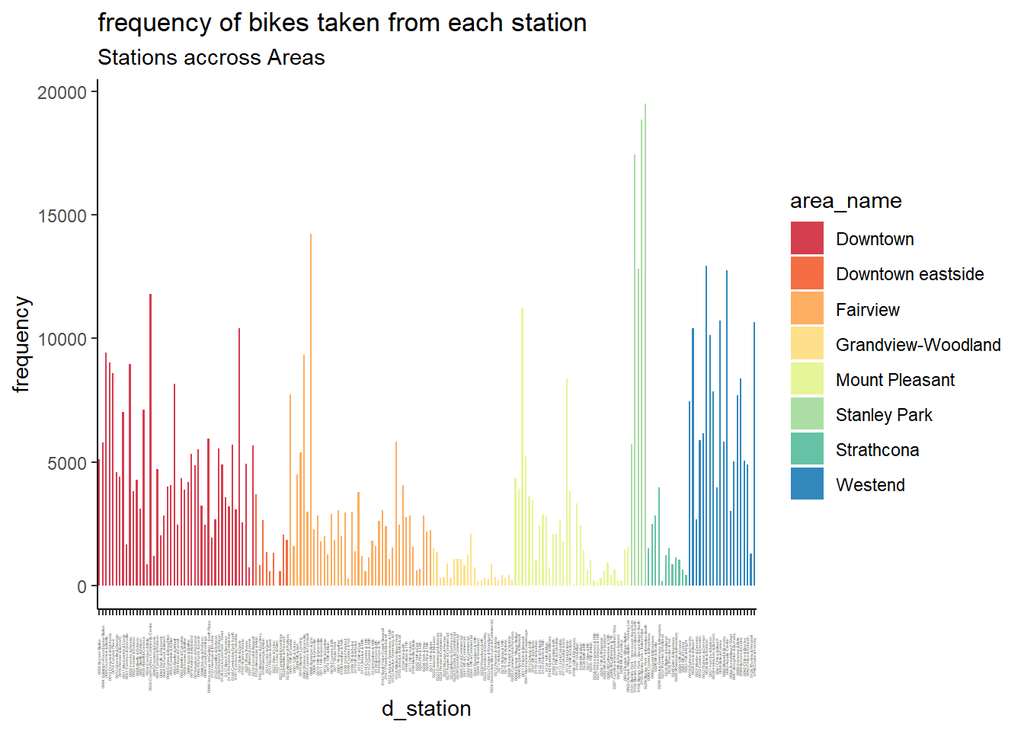

```r
freq_Area=freq_Area[order(freq_Area$area_name),]
fArea=data.frame(d_station=freq_Area$d_station,frequency=freq_Area$frequency,area_name=freq_Area$area_name)
fArea$d_station <- factor(fArea$d_station, levels = fArea$d_station)
g <- ggplot(data = fArea, aes(x=d_station,y=frequency)) + scale_fill_brewer(palette = "Spectral")

g <- g + geom_bar(aes(x=d_station,y=frequency,fill=area_name), stat="identity" ,width = 0.5) +
  theme(axis.text.x = element_text(angle=90, vjust=0.2, size=2)) +
  labs(title="frequency of bikes taken from each station",
       subtitle="Stations accross Areas")
ggsave("output/frequency-Stations.tiff", units="in", width=20, height=8, dpi=300, compression = 'lzw')
g
```

This graph represents the relationship between the departure stations and the frequency of bikes taken from that station. Plus, it divides all those stations into eight areas based on their locations, which are displayed in different colors. From this graph, we could firstly conclude that different areas have different number of locations, and they vary greatly. For example, the Stanley Park has the highest frequency of riding bikes but owns the lowest number of bike stations. On the other hand, for the Grandview-Woodland area, it has larger number of stations but lower frequency of riding bikes. Based on this conclusion, we recommend that Mobi should clarify the relationship between the departure stations and the frequency of riding bikes in a deep extent to arrange more bikes in the area with higher frequency of riding bikes, and then obtain more profits.

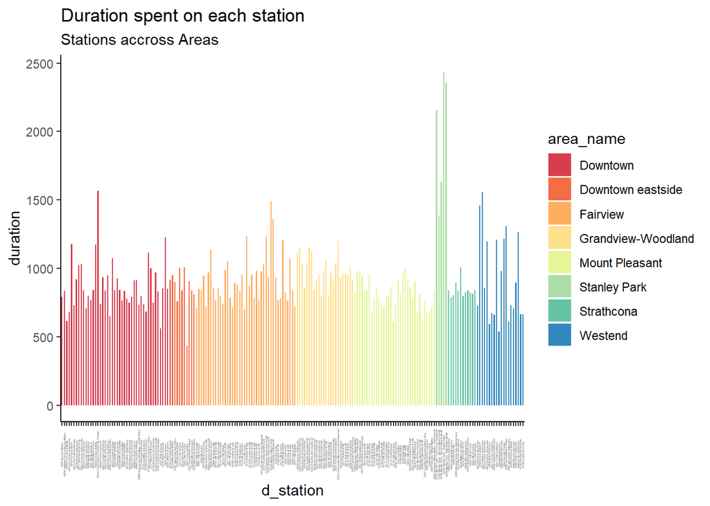

```r
Area=Area[order(Area$area_name),]
SArea=data.frame(d_station=Area$d_station,duration=Area$duration,area_name=Area$area_name)
SArea$d_station <- factor(SArea$d_station, levels = SArea$d_station)
g <- ggplot(data = SArea, aes(x=d_station,y=duration)) + scale_fill_brewer(palette = "Spectral")

g <- g + geom_bar(aes(x=d_station,y=duration,fill=area_name), stat="identity" ,width = 0.5) +
  theme(axis.text.x = element_text(angle=90, vjust=0.2, size=2)) +
  labs(title="Duration spent on each station",
       subtitle="Stations accross Areas")
ggsave("output/duration-Stations.tiff", units="in", width=20, height=8, dpi=300, compression = 'lzw')
g
```

This graph shows the relationship between departure stations and the duration spent on each station. Similar to the graph above, it also divides all those stations into eight areas based on their locations, which are displayed in different colors. From this graph, we could conclude that the largest duration happens in Stanley Park which has the lowest number of bike stations and the lowest duration happens in Downtown eastside. In addition, the average duration among all stations except Stanley Park is similar. From this perspective, we recommend that Mobi should put more riding bikes to gain more profits.

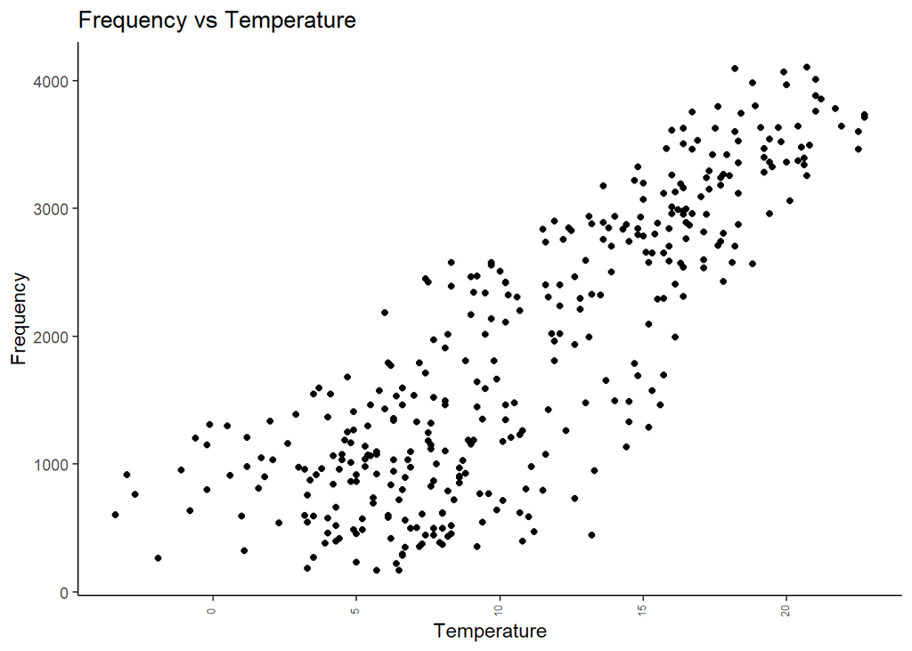

```r
options(digits=6)
fArea=data.frame(Temperature=as.double(freq_weather$mean_temp),Usage=as.double(freq_weather$num_dep))
fArea=fArea[order(fArea$Temperature),]
#fArea$Temperature <- factor(fArea$Temperature, levels = unique(fArea$Temperature))
g <- ggplot(data = fArea, aes(x=Temperature,y=Usage)) + scale_fill_brewer(palette = "Spectral")

g <- g + geom_point() +
  theme(axis.text.x = element_text(angle=90, vjust=0.2, size=6)) +
  labs(title="Frequency vs Temperature")+xlab("Temperature")+ylab("Frequency")
g<-g + scale_x_continuous(breaks = seq(-5, 25, by = 5))
ggsave("output/Frequency-weather.tiff", units="in", width=10, height=8, dpi=300, compression = 'lzw')
g
```

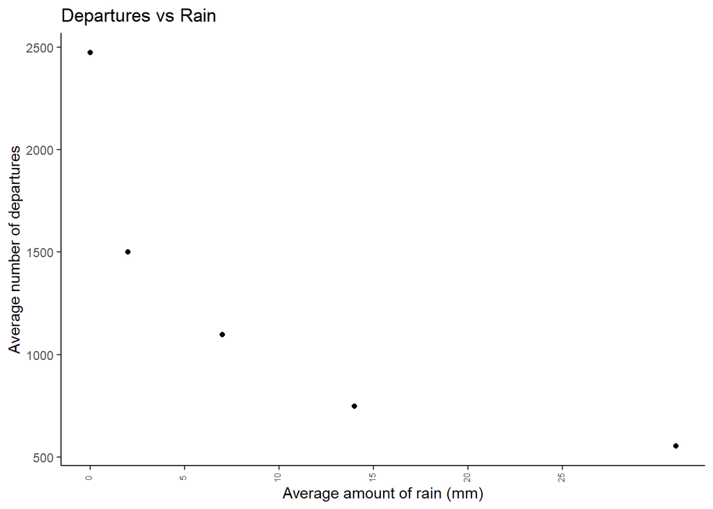

```r
options(digits=6)
fArea=data.frame(Rain=as.double(freq_rain$avg_rain),Usage=as.double(freq_rain$avg_dep))
fArea=fArea[order(fArea$Rain),]
#fArea$Temperature <- factor(fArea$Temperature, levels = unique(fArea$Temperature))
g <- ggplot(data = fArea, aes(x=Rain,y=Usage)) + scale_fill_brewer(palette = "Spectral")

g <- g + geom_point() +
  theme(axis.text.x = element_text(angle=90, vjust=0.2, size=6)) +
  labs(title="Departures vs Rain")+xlab("Average amount of rain (mm)")+ylab("Average number of departures")
g<-g + scale_x_continuous(breaks = seq(-5, 25, by = 5))
g
```

This graph shows the average number of bike departures based on the average amount of rain in 2018. Based on this graph when the average amount of rain is increased from 0 to more than 25 mm, the average number of bike departures is decreases from almost 2500 to less than 700. Therefore,the more the amount of rain, the less the demand for bike sharing. Considering the relation between bike departures and amount of rain, Mobi can estimate the number of bike departures based on the weather forecast

## Cost side

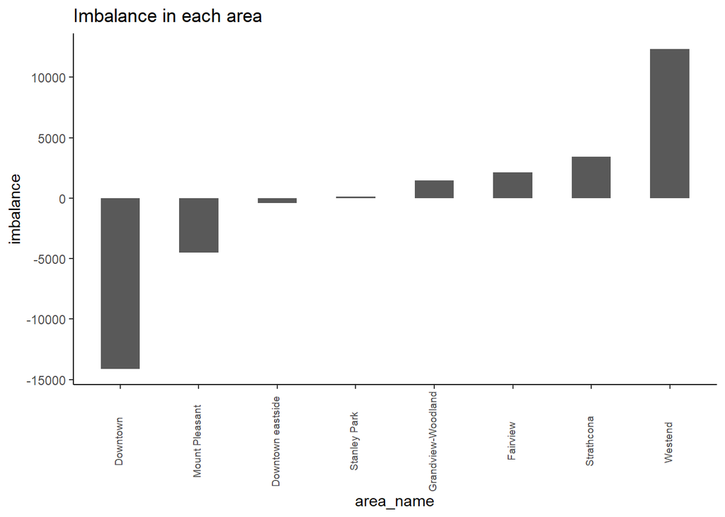

```r
imb_Area_new=imb_Area_new[order(imb_Area_new$imbalance),]
IArea_new=data.frame(Area=imb_Area_new$area_name,imbalance=strtoi(imb_Area_new$imbalance),area_name=imb_Area_new$area_name)
IArea_new=IArea_new[order(IArea_new$imbalance),]
IArea_new$area_name <- factor(IArea_new$area_name, levels = IArea_new$area_name)
g <- ggplot(data = IArea_new, aes(x=area_name,y=imbalance))+scale_color_brewer(palette="Spectral")

g <- g + geom_bar(aes(x=area_name,y=imbalance), stat="identity" ,width = 0.5) +
  theme(axis.text.x = element_text(angle=90, vjust=0.2, size=7)) +
  labs(title="Imbalance in each area")
ggsave("output/imbalance-area-new.tiff", units="in", width=8, height=8, dpi=300, compression = 'lzw')
g
```

This graph is about area versus imbalance. To calculate imbalance, we use # of bikes departed from an area minus # of bikes get returned to this area. For example, Downtown has the imbalance at around -14000, it means throughout the whole year, there are total 14000 more bikes are returned to this area than departed. Whereas, in Westend, there are roughly 12,000 bikes being departed more than return.

Although this information has no relationship with customers and usage, it is essential for company to reduce the cost of bike arrangement. Since these two areas are neighbor, the analysis seems to indicate that in terms of redistribution, the company can focus the distribution route between Downtown and Westend instead of running overall the operating area.  
In addition, By knowing which areas are expected to need more bikes and which areas need less, we can arrange the bike more efficiently at the very beginning so that to avoid any unnecessary costs later.

# **Section 6: Conclusion**

Using data on usage of Mobi Bike-share in 2018, we analyzed the pattern of bike usage under different time periods and areas. We identified the frequency of the usage as a factor affecting Mobi’s revenue and the difference between the departing and returning bike at any station as a factor affecting Mobi’s cost, since the bike would have to be physically moved back to the station with high departure rate. Lastly, We’ve added an additional data on weather to further refine our analysis to include the effect of temperature and rainfall on frequency of bike sharing.

When analyzing the number of bikes have been taken from and returned to different stations, we found that there exists some imbalance. Hence, to avoid the situation where the people who want to get a bike facing an empty station and people who want to return the bike facing a fully loaded station, Mobi would have to invest in redistributing these bikes back. By analyzing the imbalance, we can suggest Mobi to make a wiser decision when distributing the bikes to avoid such situation which are both harmful to the profit and service level of the company.

#### Reference

Bergman, J. V. (n.d.). Vancouver Bike Share. Retrieved September 18, 2019, from https://mountainmath.ca/mobi/map#14/49.2771/-123.1234.

Cho, Michelle. (2019). Vancouver bike sharing 2018. Retrieved from https://data.world/michellecho/vancouver-bike-sharing-2018/contributors

List of Neighborhoods in Vancouver. (n.d.). In Wikipedia. Retrieved August 10, 2004, from https://en.wikipedia.org/wiki/List_of_neighbourhoods_in_Vancouver

Government of Canada. (2019). Daily Data Report for October 2018. Retrieved from https://climate.weather.gc.ca/climate_data/daily_data_e.html?StationID=51442&format=csv&timeframe=2&StartYear=1840&EndYear=2019&Day=3&Year=2018&Month=10#